# R Notebook

This script reads in both PBMC and Liver Seurat objects, and generates select figures used in the manuscript.

## Prepare objects

Load libraries

```r
library(Seurat)
library(scClustViz)
library(ggplot2)
library(dplyr)
library(rcartocolor)
library(SeuratWrappers)
library(scCustomize)
```

Read in liver map

```r
sobj <- readRDS("~/Dropbox/Zoe/scf_version/analysis/healthy_sc/seurat_objects/dropletQC_filtered/allIntegrated_cca_kanchor5_noBiopsyHeps_dropletQCFiltered.RDS")
res <- "integrated_snn_res.1.4"
Idents(sobj) <- res
tissue <- "liver"
```

Read in PBMC map

```r
load("~/Dropbox/Zoe/scf_version/analysis/healthy_sc/seurat_objects/no_dropletQC/integrated_PBMC_cca_kanchor5_scClustViz.RData")
sobj <- scSeurat
res <- "integrated_snn_res.0.6"
Idents(sobj) <- res
tissue <- "PBMC"
```

## Visualization of metadata

UMAP with no cluster numbers

```r
plot <- DimPlot(sobj, label = FALSE) & NoLegend()
plot
pdf(paste("./figures/", tissue, "/", tissue, "_UMAP_clusters_noLabels.pdf", sep = ""))
plot
dev.off()
```

UMAP with cluster numbers

```r
plot <- DimPlot(sobj, label = TRUE)
plot
pdf(paste("./figures/", tissue, "/", tissue, "_UMAP_clusters_labels.pdf", sep = ""))
plot
dev.off()
```

Map with SCINA-generated cell-type labels

```r
DimPlot(sobj, group.by = "scina_labels_refined", label = TRUE) & NoLegend()
```

Map with general cell-type labels for paper

```r
plot <- DimPlot(sobj, group.by = "general_cell_labels",
        label = TRUE, repel = TRUE) +
  ggtitle(NULL)
plot
pdf(paste("./figures/", tissue, "/", tissue, "_UMAP_general_cell_labels.pdf", sep = ""),
    height = 8,
    width = 12)
plot
dev.off()
```

Map grouping by general cell type labels but with no labels on plot

```r
plot <- DimPlot(sobj, group.by = "general_cell_labels") +
  ggtitle(NULL) &
  NoLegend()
plot
pdf(paste("./figures/", tissue, "/", tissue, "_UMAP_general_cell_labels_noLabels.pdf",
          sep = ""))
plot
dev.off()
```

Map with original identities

```r
plot <- DimPlot(sobj, group.by = "orig.ident",
        cols = carto_pal(length(levels(as.factor(sobj$orig.ident))), "Safe")) +
  ggtitle(NULL)
plot
pdf(paste("./figures/", tissue, "/", tissue, "_UMAP_orig_idents.pdf",
          sep = ""),
    height = 5, width = 7)
plot
dev.off()
```

Barplot with original identities on a cluster-level grouping:

```r
# Meta data to plot:
df <- sobj@meta.data
# Check what column the cluster identities are in
col <- which(colnames(df) == res)
# Order clusters
df[,col] <- factor(Idents(sobj),
                             levels = c(sort(as.numeric(levels(Idents(sobj))))))
# Basic plot of clusters by replicate
ggplot(df, aes(x = get(res), fill = orig.ident)) +
  geom_bar() +
  theme(axis.text = element_text(size = 7))
# Plot as proportion or percentage of cluster
ggplot(df, aes(x = get(res), fill = orig.ident)) +
  geom_bar(position = "fill") +
  theme(axis.text = element_text(size = 7))
```

Barplot with original identities on a grouped by general cell labels:

```r
df <- sobj@meta.data
plot1 <- ggplot(df, aes(x = general_cell_labels, fill = orig.ident)) +
  geom_bar() +
  scale_fill_carto_d(name = NULL, palette = "Safe") +
  theme_bw() +
  theme(axis.text = element_text(size = 8),
        axis.text.x = element_text(angle = 90, vjust = 0.5, hjust=1),
        axis.title.x = element_blank()) +
  ylab("Number of cells")
plot1
pdf(paste("./figures/", tissue, "/", tissue, "_barplot_orig_ident_counts.pdf",
          sep = ""))
plot1
dev.off()
# Plot as proportion or percentage of cluster
plot2 <- ggplot(df, aes(x = general_cell_labels, fill = orig.ident)) +
  geom_bar(position = "fill") +
  scale_fill_carto_d(name = NULL, palette = "Safe") +
  theme_bw() +
  theme(axis.text = element_text(size = 8),
        axis.text.x = element_text(angle = 90, vjust = 0.5, hjust=1),
        axis.title.x = element_blank()) +
  ylab("Proportion of cells")
plot2
pdf(paste("./figures/", tissue, "/", tissue, "_barplot_orig_ident_proportions.pdf",
          sep = ""))
plot2
dev.off()
```

## Dotplots

Generate dotplot with specific markers

```r
DotPlot(sobj,
        assay = "SCT",
        features = c("PTPRC", "CALCRL", "NKG7", "CD3E", "MARCO", "LYZ-1", "CD19", "MS4A1", "STAB2")
        ) +
  ggtitle("Select features for liver map")
```

## Heatmaps

Calculate markers for general cell labels then reset resolution

```r
Idents(sobj) <- "general_cell_labels"
sobj_markers <- RunPrestoAll(sobj,
                             only.pos = TRUE,
                             min.pct = 0.25,
                             logfc.threshold = 0.25)
sobj_markers %>%
    group_by(cluster) %>%
    slice_max(n = 2, order_by = avg_log2FC)
Idents(sobj) <- res
```

Save markers

```r
groups = "general_cell_labels"
write.table(sobj_markers,
            file = paste("./figures/", tissue, "/",
                         tissue, "_markers_", groups, ".tsv",
                         sep = ""),
            quote = FALSE,
            sep = "\t",
            row.names = FALSE,
            col.names = TRUE)
```

Generate heatmap with top 5 markers grouping by general cell types

```r
# Remove mikado genes from marker list
sobj_markers <- sobj_markers[grep("mikado", rownames(sobj_markers), invert = TRUE),]
sobj_markers %>%
    group_by(cluster) %>%
    top_n(n = 5, wt = avg_log2FC) -> top
# If liver, select fewer cells
if (tissue == "liver") {
  cells <- sample(colnames(sobj), size = 30000)
} else if (tissue == "PBMC") {
  cells <- colnames(sobj)
}
DoHeatmap(sobj, features = top$gene, group.by = "general_cell_labels", size = 3,
          angle = 90, cells = cells) +
  NoLegend() +
  theme(text = element_text(size = 7))
```

Make PDF of heatmap

```r
groups <- "general_cell_labels"
pdf(paste("./figures/", tissue, "/", tissue, "_heatmap_", groups, ".pdf", sep = ""),
    height = 13,
    width = 7)
DoHeatmap(sobj, features = top$gene, group.by = "general_cell_labels", size = 2,
          angle = 90, cells = cells) +
  NoLegend() +
  theme(text = element_text(size = 7))
dev.off()
```

## Feature plots

Make specific plots with specific genes. The genes we are interested in include: *PTPRC, CALCRL, NKG7, CD3E, MARCO, LYZ, CD19, MS4A1, STAB2, ALB, CD4, CD8A, CLEC4G, CD5L, C1QB, ACTA2, VWF, IGLL5, CD68*. Can also plot in italics.

```r
geneCode <- "sct_LYZ-1" # Woodchuck-specific nomenclature for this genome
gene <- "LYZ"
mapType <- "Liver"
FeaturePlot(sobj, features = geneCode) +
  ggtitle(paste(gene, "-", mapType, "map"))
FeaturePlot(sobj, features = geneCode) +
  ggtitle(bquote(~italic(.(gene))))
```

Another version of the feature plot that outputs genes in italics

```r
if (tissue == "PBMC") {
 geneCodes <- c("sct_PTPRC","sct_NKG7","sct_CD14",
               "sct_CD3E","sct_MARCO","sct_LYZ-1",
               "sct_CD19","sct_MS4A1","sct_STAB2",
               "sct_CD4","sct_CD8A", "sct_XCL1;XCL2",
               "sct_CD5L","sct_C1QB", "sct_LEF1",
               "sct_ACTA2","sct_VWF","sct_IGLL5-1",
               "sct_CD68","sct_FCGR3A;FCGR3B","sct_TOP2A")
 genes <- c("PTPRC","NKG7","CD14","CD3E","MARCO","LYZ",
           "CD19","MS4A1","STAB2","CD4","CD8A", "XCL1;XCL2",
           "CD5L","C1QB","LEF1","ACTA2","VWF","IGLL5","CD68",
           "FCGR3A;FCGR3B","TOP2A")
} else if (tissue == "liver") {
  geneCodes <- c("sct_Ptprc","sct_CALCRL","sct_NKG7",
                 "sct_CD3E","sct_MARCO","sct_LYZ-1",
                 "sct_CD19","sct_MS4A1","sct_STAB2",
                 "sct_ALB-1","sct_CD4","sct_CD8A",
                 "sct_CLEC4G","sct_CD5L","sct_C1QB",
                 "sct_ACTA2","sct_VWF","sct_IGLL5-1",
                 "sct_CD68","sct_XCL1;XCL2","sct_LEF1",
                 "sct_RSPO3","sct_MECOM")
  genes <- c("PTPRC","CALCRL","NKG7","CD3E","MARCO","LYZ",
             "CD19","MS4A1","STAB2","ALB","CD4","CD8A",
             "CLEC4G","CD5L","C1QB","ACTA2","VWF","IGLL5","CD68",
             "XCL1;XCL2","LEF1","RSPO3","MECOM")
}
for(num in 2:length(geneCodes)) {
  plot <- FeaturePlot(sobj,
                      features = geneCodes[num]) +
    ggtitle(bquote(~italic(.(genes[num]))))
  print(plot)
  pdf(paste("./figures/", tissue, "/", tissue, "_", genes[num], "_UMAP.pdf", sep = ""))
  print(plot)
  dev.off()
}
```

### Cell-population-specific markers

Plot marker genes for specific cell populations

Endothelial cells:

```r
geneCodes <- c("STAB2","ITGA1","CD55","LYVE1",
               "CD34","VWF","IFITM3;IFITM2;IFITM1","RSPO3",
               "MECOM","Mecom","CALCRL","LOC114089654",
               "RAMP2","BST2","CLEC4G","CTSV;CTSL",
               "STAB1","PLAC9","PECAM1","WNT2",
               "MYL6","NR2F2")
genes <- c("STAB2","ITGA1","CD55","LYVE1",
           "CD34","VWF","IFITM3","RSPO3",
           "MECOM","Mecom","CALCRL","LOC114089654",
           "RAMP2","BST2","CLEC4G","CTSV;CTSL",
           "STAB1","PLAC9","PECAM1","WNT2",
           "MYL6","NR2F2")
for(num in 1:length(geneCodes)) {
  plot <- FeaturePlot_scCustom(sobj,
                               features = geneCodes[num],
                               colors_use = viridis_light_high) +
    ggtitle(bquote(~italic(.(genes[num]))))
  print(plot)
  pdf(paste("./figures/", tissue, "/", tissue, "_", genes[num], "_UMAP.pdf", sep = ""))
  print(plot)
  dev.off()
}
```

Highlight endothelial cluster:

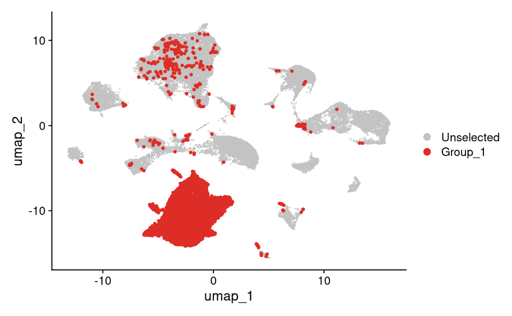

```r
cells <- WhichCells(sobj, idents = "Endothelial")
DimPlot(sobj, cells.highlight = cells)
```

```r
Cell_Highlight_Plot(sobj, cells_highlight = cells)
```

[output not shown]

Lymphocytes:

```r
geneCodes <- c("CXCR3","IL7R-1",
               "S100A4","GATA3","CD247","MAF",
               "CCR4")
genes <- geneCodes
geneCodes <- c("CD3D","CD3E","CD8A","NKG7",
               "KLRD1","KLRB1","GZMA","LEF1",
               "IL7R-1","EOMES","TIGIT","XCL1;XCL2",
               "TOX","CTLA4","CD4","GZMK")
genes <- c("CD3D","CD3E","CD8A","NKG7",
           "KLRD1","KLRB1","GZMA","LEF1",
           "IL7R","EOMES","TIGIT","XCL1;XCL2",
           "TOX","CTLA4","CD4","GZMK")
for(num in 1:length(geneCodes)) {
  plot <- FeaturePlot_scCustom(sobj,
                      features = geneCodes[num],
                      colors_use = viridis_light_high) +
    ggtitle(bquote(~italic(.(genes[num]))))
  print(plot)
  pdf(paste("./figures/", tissue, "/", tissue, "_", genes[num], "_UMAP.pdf", sep = ""))
  print(plot)
  dev.off()
}
```

Lymphocytes weird genes:

```r
geneCodes <- c("sct_CCR7")
genes <- geneCodes
#plot <- FeaturePlot_scCustom(sobj,
#                      features = geneCodes,
#                      colors_use = viridis_light_high) +
#    ggtitle(bquote(~italic(.(genes))))
plot <- FeaturePlot(sobj, features = "sct_CCR7")
print(plot)
```

Mesenchyme:

```r
geneCodes <- c("HHIP","COL1A2","COL3A1","IGFBP7",
               "IGFBP3","DCN","COL1A1","SPARC",
               "RBP1", "CALCRL")
genes <- c("HHIP","COL1A2","COL3A1","IGFBP7",
           "IGFBP3","DCN","COL1A1","SPARC",
           "RBP1","CALCRL")
for(num in 1:length(geneCodes)) {
  plot <- FeaturePlot_scCustom(sobj,
                      features = geneCodes[num],
                      colors_use = viridis_light_high) +
    ggtitle(bquote(~italic(.(genes[num]))))
  print(plot)
  pdf(paste("./figures/", tissue, "/", tissue, "_", genes[num], "_UMAP.pdf", sep = ""))
  print(plot)
  dev.off()
}
```

Cholangiocytes:

```r
geneCodes <- c("KRT19","CFTR","EPCAM","SLC4A4")
genes <- c("KRT19","CFTR","EPCAM","SLC4A4")
for(num in 1:length(geneCodes)) {
  plot <- FeaturePlot_scCustom(sobj,
                      features = geneCodes[num],
                      colors_use = viridis_light_high) +
    ggtitle(bquote(~italic(.(genes[num]))))
  print(plot)
  pdf(paste("./figures/", tissue, "/", tissue, "_", genes[num], "_UMAP.pdf", sep = ""))
  print(plot)
  dev.off()
}
```

Look at zonation gene signatures:

```r
cv_genes <- c("FETUB","HMGCS1","CYP2E1","GLUD1;GLUD2","CYP1A2",
              "RGN","INMT","COMT","FDPS","SPR-1")
cv_genes
pp_genes <- c("Saa2;Saa1-1","HAMP","APOA1","APOC2","CRYL1",
              "AMY1A;AMY1C;AMY1B;AMY2A;AMY2B","MT-ATP6","UROC1",
              "APOA2","MT-CO3")
pp_genes
```

### Cell-type markers all in one plot

Hepatocytes:

```r
geneCodes <- c("CYP2E1","FETUB","HMGCS1","GLUD1;GLUD2",
               "CYP1A2","APOC2","Saa2;Saa1-1", "HAMP",
               "PCK1")
plot <- FeaturePlot_scCustom(sobj,
                     features = geneCodes,
                     colors_use = viridis_light_high,
                     num_columns = 4)
plot
pdf(paste("./figures/", tissue, "/", tissue, "_hepatocyteMarkers_UMAP.pdf", sep = ""),
    height = ceiling(length(geneCodes)/4)*6, width = 24)
plot
dev.off()
```

Endothelial cells:

```r
geneCodes <- c("CLEC4G","STAB1","STAB2","LYVE1",
               "CD34","MECOM","VWF","BMX",
               "RSPO3","WNT2","ACKR1")
plot <- FeaturePlot_scCustom(sobj,
                     features = geneCodes,
                     colors_use = viridis_light_high,
                     num_columns = 4)
plot
pdf(paste("./figures/", tissue, "/", tissue, "_endothelialMarkers_UMAP.pdf", sep = ""),
    height = ceiling(length(geneCodes)/4)*6, width = 24)
plot
dev.off()
```

T lymphocytes

```r
geneCodes <- c("CD3D","CD3E","CD4","CD8A",
               "CTLA4","IL7R-1","LEF1","EOMES",
               "TIGIT","KLRB1","KLRD1","NKG7",
               "XCL1;XCL2","TOX","GZMA","GZMK")
geneCodes <- c("CD3D","CD3E","GIMAP1","GIMAP4",
               "GIMAP6","GIMAP7","CD4","CD28",
               "FOXP1","CTLA4","CD38","XCL1;XCL2",
               "IL2RA","NKG7","CD8A","CCL5",
               "CD69","CD2","GZMK","BRCA2",
               "TOP2A", "STMN1")
plot <- FeaturePlot_scCustom(sobj,
                     features = geneCodes,
                     colors_use = viridis_light_high,
                     num_columns = 4)
plot
pdf(paste("./figures/", tissue, "/", tissue, "_lymphocyteMarkers_UMAP.pdf", sep = ""),
    height = ceiling(length(geneCodes)/4)*6, width = 24)
plot
dev.off()
```

T lymphocytes for PBMCs

```r
geneCodes <- c("CD3D","CD3E","XCL1;XCL2","NKG7",
               "LEF1","IL7R-1","GATA3","MAF",
               "CCR4","S100A4","CXCR3","IL2RA",
               "CD160","CD247","BRCA2","STMN1")
# CCR7 and TCF7 aren't showing up???
plot <- FeaturePlot_scCustom(sobj,
                     features = geneCodes,
                     colors_use = viridis_light_high,
                     num_columns = 4,
                     slot = "data")
plot
pdf(paste("./figures/", tissue, "/", tissue, "_lymphocyteMarkers_UMAP.pdf", sep = ""),
    height = ceiling(length(geneCodes)/4)*6, width = 24)
plot
dev.off()
```

Mesenchyme:

```r
geneCodes <- c("DCN","COL1A2","COL3A1","HHIP",
               "CALCRL","SPARC","RBP1","COL1A1",
               "IGFBP3", "IGFBP7")
geneCodes <- c("COL1A2", "COL3A1", "IGFBP7", "IGFBP3",
               "DCN", "CALCRL", "COL1A1", "SPARC",
               "RBP1", "HHIP","RBP1","LRAT",
               "PDE3B","HGF","CNN2","ACTA2")
plot <- FeaturePlot_scCustom(sobj,
                     features = geneCodes,
                     colors_use = viridis_light_high,
                     num_columns = 4)
plot
pdf(paste("./figures/", tissue, "/", tissue, "_mesenchymalMarkers_UMAP.pdf", sep = ""),
    height = ceiling(length(geneCodes)/4)*6, width = 24)
plot
dev.off()
```

Cholangiocytes:

```r
geneCodes <- c("KRT19","SLC4A4","CFTR","EPCAM")
geneCodes <- c("ANXA2", "CST3", "BIRC3", "TESC",
               "KRT19", "SOX9", "EPCAM","SLC4A4",
               "CFTR")
plot <- FeaturePlot_scCustom(sobj,
                     features = geneCodes,
                     colors_use = viridis_light_high,
                     num_columns = 4)
plot
pdf(paste("./figures/", tissue, "/", tissue, "_cholangiocyteMarkers_UMAP.pdf", sep = ""),
    height = ceiling(length(geneCodes)/4)*6, width = 24)
plot
dev.off()
```

Myeloid cells

```r
geneCodes <- c("TYROBP","CD74","CTSS","VSIG4",
               "MARCO", "CD5L","HMOX1","VCAM1",
               "ITGAM","FCGR3A;FCGR3B","Fcgr3;Fcgr2b","CTSA",
               "IL17RA-1","SIRPA;SIRPB1;SIRPG","BTLA", "CADM1",
               "ID2","LY6E","FLT3", "CD14",
               "NOTCH2","LYZ-1","S100A8")
plot <- FeaturePlot_scCustom(sobj,
                     features = geneCodes,
                     colors_use = viridis_light_high,
                     num_columns = 4)
plot
pdf(paste("./figures/", tissue, "/", tissue, "_myeloidMarkers_UMAP.pdf", sep = ""),
    height = ceiling(length(geneCodes)/4)*6, width = 24)
plot
dev.off()
```

## Correlation plots

Generate heatmaps comparing woodchuck clusters with various datasets

### Setup for all correlations

First, set up whatever woodchuck dataset I am working with by reading in the ortholog table, choosing whether the orthologs to use are human, mouse, or woodchuck, and calculating the average expression for each cluster. The output of this section is the scaled cluster gene-expression matrix

```r
#groups <- res
groups <- "general_cell_labels"
# Read in ortholog table
geneNameTable <- read.table("~/Dropbox/Zoe/scf_version/make_gtf/orthofinder_sc2/homologene/collectedOrthofinderPairings.tsv",
                            sep = "\t",
                            header = TRUE)
woodchuckClusterAverages <- AverageExpression(sobj,
                                              assays = "SCT",
                                              slot = "scale.data",
                                              group.by = groups)
# Scale data
woodchuckClusterAverages$SCT <- na.omit(t(scale(t(as.matrix(woodchuckClusterAverages$SCT)))))
# Grab gene names from Seurat object
uniqueHier <- row.names(woodchuckClusterAverages$SCT)
uniqueHier <- as.data.frame(uniqueHier)
# Bind with geneNameTable to get correct order (notice uniqueHier is on left)
newNames <- dplyr::left_join(uniqueHier, geneNameTable, by = "uniqueHier")
# Get orthologs from either mouse or human
species <- "human"
if (species == "human") {
  # If human one-to-one ortho has NA, replace with mikado_final_sc2_stringent_noMito_protein column
  # This is to avoid and potential mistakes in recognizing things it shouldn't be recognizing
  newNames$speciesOneToOne <- ifelse(is.na(newNames$humanOneToOne), newNames$uniqueHier, newNames$humanOneToOne)
} else if (species == "mouse") {
  newNames$speciesOneToOne <- ifelse(is.na(newNames$mouseOneToOne), newNames$uniqueHier, newNames$mouseOneToOne)
} else if (species == "woodchuck") {
  newNames$speciesOneToOne <- newNames$uniqueHier
}
# Grab dataframe
woodchuckClusterAverages <- woodchuckClusterAverages$SCT
# Replace names with one-to-one orthologue of particular species
row.names(woodchuckClusterAverages) <- newNames$speciesOneToOne
# Make sure formatted correctly
woodchuckClusterAverages <- as.data.frame(woodchuckClusterAverages)
# Order by gene name
woodchuckClusterAverages <- woodchuckClusterAverages[order(row.names(woodchuckClusterAverages)),]
# Sanity check
head(woodchuckClusterAverages)
```

### Dataset-specific setup

Correlation of woodchuck PBMCs with human 68k PBMC dataset from 10X Genomics

```r
# Now need to read in 68K PBMC data
humanPBMC <- read.csv("~/Dropbox/Zoe/scf_version/analysis/correlationTests/68K_pbmc_data/68K_enrichedGenes.csv",
                      header = FALSE)
# Get rid of top row
humanPBMC <- humanPBMC[-1,]
# Separate all cell and myloid cell data
allCells <- select(humanPBMC, V1, V2, V3)
myeloid <- select(humanPBMC, V5, V6, V7)
# Rename and get rid of first row
colnames(allCells) <- c("Cluster", "Gene", "Enrichment")
colnames(myeloid) <- c("Cluster", "Gene", "Enrichment")
# Get rid of top row
allCells <- allCells[-1,]
myeloid <- myeloid[-1,]
# I can then filter the rows and bind the data frames back together by gene name
for (j in 1:10) {
  dat <- dplyr::filter(allCells, Cluster == j)
  #dat <- get(paste("allCells", j, sep = ""))
  # Multiply enrichment values by -1 because the signs are backwards???
  dat$Enrichment <- as.numeric(dat$Enrichment) * -1
  dat <- dplyr::select(dat, Gene, Enrichment)
  colnames(dat) <- c("Gene", paste("Enrichment", j, sep = ""))
  if (j == 1) {
    allCellsMatrix <- dat
  }
  else {
    allCellsMatrix <- dplyr::full_join(allCellsMatrix, dat, by = "Gene")
  }
}
# Make row names gene names
rownames(allCellsMatrix) <- allCellsMatrix$Gene
allCellsMatrix <- dplyr::select(allCellsMatrix, -Gene)
# Make column names cell types
colnames(allCellsMatrix) <- c("Activated CD8+", "Naive CD8+", "Memory and Reg T",
                              "Naive CD4+", "NK", "CD8+", "B", "Megakaryocytes",
                              "Monocytes and Dendritic", "B, Dendritic, T")
# Scale across columns
allCellsMatrix <- t(scale(t(allCellsMatrix)))
# Order genes alphabetically by gene name
allCellsMatrix <- allCellsMatrix[order(row.names(allCellsMatrix)),]
# Sanity check
head(allCellsMatrix)
speciesData <- "68KPBMC"
```

Correlation of woodchuck liver with human liver dataset from MacParland *et al.* (2018)

```r
# Find cluster averages of human liver data
load("~/Dropbox/Zoe/scf_version/analysis/correlationTests/HumanLiver.RData")
# Run SCTransform
HumanLiverSeurat <- UpdateSeuratObject(HumanLiverSeurat)
HumanLiverSeurat <- SCTransform(HumanLiverSeurat)
humanClusterAverages <- AverageExpression(HumanLiverSeurat,
                                          assays = "SCT",
                                          slot = "scale.data")
# Replace cluster numbers with names
colnames(humanClusterAverages$SCT) <- c("Hep 1", "Alpha-beta T cells", "Hep 2",
                                        "Inflammatory macs", "Hep 3", "Hep 4",
                                        "Plasma cells", "NK-like cells", "Gamma-delta T cells",
                                        "Non-inflammatory macs", "Periportal LSECs", "Central venous LSECs",
                                        "Portal endothelial cells", "Hep 5", "Hep 6",
                                        "Mature B cells", "Cholangiocytes", "Gamma-delta T cells 2",
                                        "Erythroid cells", "Hepatic stellate cells")
# If only looking at specific clusters
#humanClusterAverages$SCT <- humanClusterAverages$SCT[,c("3","1","15","6","14","5")]
# Otherwise go straight to here:
humanClusterAverages$SCT <- na.omit(t(scale(t(as.matrix(humanClusterAverages$SCT)))))
# Grab gene names
humanGenes <- row.names(humanClusterAverages$SCT)
# Now turn into large dataframe
allCellsMatrix <- as.data.frame(humanClusterAverages$SCT)
# Order by row name
allCellsMatrix <- allCellsMatrix[order(row.names(allCellsMatrix)),]
# Sanity check
head(allCellsMatrix)
speciesData <- "macparland"
```

Correlation of woodchuck liver with human liver dataset from Aizarani *et al.*

```r
# Read in Aizarani dataset
aizarani <- readRDS("~/Dropbox/Zoe/scf_version/analysis/correlationTests/GSE124395_Normalhumanliverdata.RData")
# Read in clusters and label cells
aizaraniClusters <- read.table("~/Dropbox/Zoe/scf_version/analysis/correlationTests/GSE124395_clusterpartition.txt")
# Only keep cells in the cluster object
aizarani <- aizarani[,intersect(colnames(aizarani),row.names(aizaraniClusters))]
# Create Seurat object
aizarani <- CreateSeuratObject(counts = aizarani)
# Run SCTransform
aizarani <- SCTransform(aizarani)
# Add cluster IDs
Idents(aizarani) <- aizaraniClusters$sct.cpart
# Get cluster averages
aizaraniAverages <- AverageExpression(aizarani,
                                      assays = "SCT",
                                      slot = "scale.data")
aizaraniAverages$SCT <- na.omit(t(scale(t(as.matrix(aizaraniAverages$SCT)))))
# Grab gene names
aizaraniGenes <- row.names(aizaraniAverages$SCT)
# Now turn into large dataframe
allCellsMatrix <- as.data.frame(aizaraniAverages$SCT)
# Order by column
allCellsMatrix <- allCellsMatrix[,as.character(sort(as.numeric(colnames(allCellsMatrix))))]
# Rename columns to be more meaningful (not totally confident I got all correct)
colnames(allCellsMatrix) <- c('NK, NKT and T cells (1)',
                              'Kupffer cells (2)',
                              'NK, NKT and T cells (3)',
                              'EPCAM+ cells and cholangiocytes (4)',
                              'NK, NKT and T cells (5)',
                              'Kupffer cells (6)',
                              'EPCAM+ cells and cholangiocytes (7)',
                              'B cells (8)',
                              'Liver sinusoidal endothelial cells (9)',
                              'Macrovascular endothelial cells (10)',
                              'Hepatocytes (11)',
                              'NK, NKT and T cells (12)',
                              'Liver sinusoidal endothelial cells (13)',
                              'Hepatocytes (14)',
                              'Other endothelial cells (15)',
                              'Other (16)',
                              'Hepatocytes (17)',
                              'NK, NKT and T cells (18)',
                              'NK, NKT and T cells (19)',
                              'Liver sinusoidal endothelial cells (20)',
                              'Macrovascular endothelial cells (21)',
                              'B cells (22)',
                              'Kupffer cells (23)',
                              'EPCAM+ cells and cholangiocytes (24)',
                              'Kupffer cells (25)',
                              'Other endothelial cells (26)',
                              'Other (27)',
                              'NK, NKT and T cells (28)',
                              'Macrovascular endothelial cells (29)',
                              'Hepatocytes (30)',
                              'Kupffer cells (31)',
                              'Macrovascular endothelial cells (32)',
                              'Stellate cells and myofibroblasts (33)',
                              'B cells (34)',
                              'Other endothelial cells (35)',
                              'Other (36)',
                              'Other (37)',
                              'B cells (38)',
                              'EPCAM+ cells and cholangiocytes (39)')
# Order by row name
allCellsMatrix <- allCellsMatrix[order(row.names(allCellsMatrix)),]
# Sanity check
head(allCellsMatrix)
speciesData <- "aizarani"
```

Correlation of woodchuck liver with human liver dataset from Andrews *et al.* (2022)

```r
# Load dataset
humanNuc <- readRDS("~/Dropbox/Zoe/scf_version/analysis/correlationTests/single_nuc_20_human_map.rds")
# Isolate single-nuc only
humanNuc <- UpdateSeuratObject(humanNuc)
humanNuc <- subset(humanNuc, subset = assay_type == "single_nuc")
# Run SCTransform
humanNuc <- SCTransform(humanNuc)
# Change idents
Idents(humanNuc) <- humanNuc@meta.data$sub_annotation
# Get cluster averages
humanNucClustAverages <- AverageExpression(humanNuc,
                                           assays = "SCT",
                                           slot = "scale.data")
humanNucClustAverages$SCT <- na.omit(t(scale(t(as.matrix(humanNucClustAverages$SCT)))))
# Grab gene names
nucGenes <- row.names(humanNucClustAverages$SCT)
# Now turn into large dataframe
allCellsMatrix <- as.data.frame(humanNucClustAverages$SCT)
# Order by row name
allCellsMatrix <- allCellsMatrix[order(row.names(allCellsMatrix)),]
# Sanity check
head(allCellsMatrix)
speciesData <- "andrews"
```

Correlation of woodchuck liver with woodchuck PBMCs. For this correlation, read in the woodchuck liver dataset at the beginning of this script and then read in the woodchuck PBMCs below

```r
groups <- "general_cell_labels"
# Start with liver and read in woodchuck PBMCs again
load("~/Dropbox/Zoe/scf_version/analysis/healthy_sc/seurat_objects/no_dropletQC/integrated_PBMC_cca_kanchor5_scClustViz.RData")
Idents(scSeurat) <- "integrated_snn_res.0.6"
# Find cluster averages
pbmcClusterAverages <- AverageExpression(scSeurat,
                                         assays = "SCT",
                                         slot = "scale.data",
                                         group.by = groups)
pbmcClusterAverages <- as.data.frame(na.omit(t(scale(t(as.matrix(pbmcClusterAverages$SCT))))))
# Order by row name
allCellsMatrix <- pbmcClusterAverages[order(row.names(pbmcClusterAverages)),]
speciesData <- "PBMC"
```

### Output plots for all correlations

```r
# Now find intersecting genes
matches <- intersect(row.names(allCellsMatrix),
                     row.names(woodchuckClusterAverages))
# Look at how many genes matched
length(matches)
# Make new matrices with only matching gene names
toCor <- allCellsMatrix[matches,]
woodchuckAveragesCor <- woodchuckClusterAverages[matches,]
# Do Pearson
pearVal <- cor(toCor, woodchuckAveragesCor, method = "pearson")
heatmap(pearVal)
        #main = paste("Pearson correlation of", speciesData, "vs", woodchuckData),
        #xlab = woodchuckData,
        #ylab = speciesData)
        #margins = c(6,11))
#Rowv = NA,
#Colv = NA)
pdf(paste("./figures/", tissue, "/", tissue, "_", speciesData, "_PearsonCor.pdf", sep = ""),
    height = 15, width = 13)
heatmap(pearVal, margins = c(13,13))
dev.off()
# Do Spearman
spearVal <- cor(toCor, woodchuckAveragesCor, method = "spearman")
heatmap(spearVal)
        #main = paste("Spearman correlation of", speciesData, "vs", woodchuckData),
        #xlab = woodchuckData,
        #ylab = speciesData)
        #margins = c(6,11))
#Rowv = NA,
#Colv = NA)
pdf(paste("./figures/", tissue, "/", tissue, "_", speciesData, "_SpearmanCor.pdf", sep = ""),
    height = 15, width = 13)
heatmap(spearVal, margins = c(13,13))
dev.off()
```